← Portfolio

Public Health Attitudes · Survey Research

# Vaccine Attitudes Survey

An 800-person survey of vaccine conspiracy endorsement compared how two audience segments rated the same counter-evidence coming from five different kinds of sources.

Sample

800 U.S. adults

Prolific; quota-balanced between vaccine-hesitant and vaccine-supportive adults

Design

Within-subjects survey (2 claims × 5 evidence sources)

Analysis

R (tidyverse, lme4); linear mixed models; Tableau Public

Headline finding

Conspiracy endorsers and non-endorsers trusted informal sources about equally. Non-endorsers trusted institutional sources (like medical journals) about 2.4 times as much as endorsers did.

01Challenge

## The same evidence lands differently depending on who delivers it

Communicators often assume the most authoritative source is the most persuasive. That doesn't hold if part of the audience distrusts a whole type of source.

Informal

Personal anecdote

Social media post

Institutional

News article

Government statement

Medical journal

This study asked whether people who reject a claim are rejecting the evidence itself or only certain sources of it.

02Methodology & scope

## Rating counter-evidence from five sources

Each participant did this twice, once for a claim that the government is lying about the COVID-19 vaccine’s safety and effectiveness and once for the same claim about pharmaceutical companies. They rated their belief in the claim, then saw evidence against it from five sources. After each source, they rated how much they trusted it and how much they now believed the claim.

The government is lying about the vaccine

Big Pharma is lying about the vaccine

1 · Rate a claim

→

2 · See counter-evidence

→

3 · Rate each source

800

Adults, Prolific

5

Evidence sources rated per claim

2

Conspiracy claims (government, pharma)

296

Endorsed at least one claim

**Segments.** Endorsers were those who rated a conspiracy as very likely to be true (4 of 4). The sample we recruited was an even split between self-identified vaccine-hesitant and vaccine-supportive adults.

**Belief change.** We measured change as the difference between a participant’s endorsement before and after seeing each piece of counter-evidence.

03Insights & recommendations

## What the data show, and what to do about it

1 Source trust

### Endorsers distrusted institutional sources specifically

Both groups gave informal sources little trust. The difference showed up for institutional sources. Medical journals were the most trusted source for non-endorsers and had the widest gap between groups.

Non-endorser Endorser

Hover a bar for the exact mean and group size.

[interactive chart not shown]

Mean trust on a 0–3 scale. Government claim: 196 endorsers, 605 non-endorsers. Pharma claim: 280 endorsers, 521 non-endorsers. Aggregated from the cleaned survey file; no individual responses are shown. Error bars show ±1 SE.

**Statistical details**

For communication & content strategy

A segment that rejects a claim isn't necessarily rejecting evidence. Segment audiences by which sources they trust as well as by what they believe, and test messengers for each segment instead of assuming the most authoritative source will be the most persuasive.

2 Belief change

### For non-endorsers, belief change followed trust. For endorsers, it didn't.

Non-endorsers showed about twice as much belief change after institutional sources (compared to informal ones), in line with how much they trusted each. Endorsers showed the same amount of change from every source.

[figure not shown]

Fig. 1 — Mean trust and reported belief change by source type, both claims pooled. Each person's informal (2 sources) and institutional (3 sources) ratings were averaged before averaging across people.

**Statistical details**

- Linear mixed model on belief change (0–3), random intercepts for participant, claim as covariate.
- Endorser × source type interaction: b = −0.58, SE = 0.03, p < .001
- Endorsers showed more change than non-endorsers from informal sources (b = 0.13, p < .001) and about the same from institutional sources (b = 0.02, p = .52)
- Trust–change correlation by source and claim: r = .09 to .43 for non-endorsers; r = −.01 to −.22 for endorsers

For message testing

With skeptical audiences, test sources directly. How much people say they trust a source didn’t tell us how much it would move them.

3 Generalized distrust

### Distrust carried across institutions

The pharma claim accused drug companies, but its endorsers distrusted government statements too. They trusted a government statement about as little as a social media post (0.24 vs. 0.22). For this group, distrust seemed to extend to institutions in general.

[figure not shown]

Informal sourceInstitutional source

Fig. 2 — Difference in mean trust between non-endorsers and endorsers for each source. Longer bars mean endorsers trusted that source less.

**Statistical details**

- Endorsers' mean trust in government statements: 0.18 (government claim), 0.24 (pharma claim), the lowest of the five sources under both claims, alongside social media (0.25, 0.22)
- 180 participants endorsed both claims; 296 endorsed at least one

For choosing a messenger

Swapping one institution for another may not help with a skeptical audience. Messengers from outside institutions, or institutional evidence shared through channels the audience already uses, are worth testing.

Why this matters beyond this study

People decide whom to learn from before they decide what to believe. Every curriculum, test item, or health campaign presents its claims through some source, but audiences don’t agree on which sources are trustworthy. Knowing which sources a segment trusts or discounts is a first step toward helping people update their beliefs.

Interactive dashboard Explore the findings in Tableau Public → How much endorsers and non-endorsers trust each source, how much each source moves their beliefs, and where to start with skeptical audiences

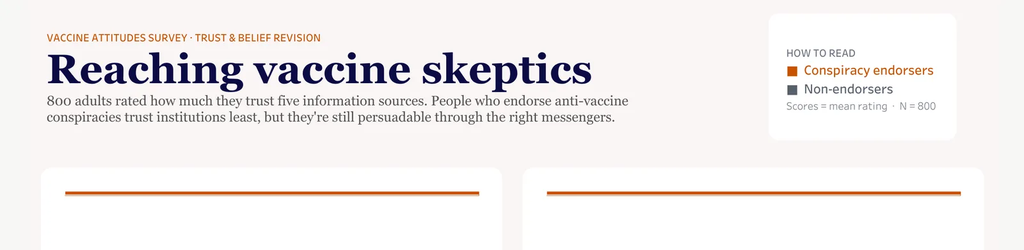